# Average Linkage Hierarchical Clustering

# Introduction

Average linkage clustering (UPGMA) merges clusters based on the **average pairwise distance** between their members. This method balances chaining (as in single linkage) and compactness (as in complete linkage).

# 1. Setting up the data

We’ll use the same example data as before (height and weight).

```r
weight.kg <- c(15,49,13,45,85,66,12,10)
height.cm <- c(95,156,95,160,178,176,90,78)

data <- matrix(cbind(weight.kg, height.cm), nrow = 8)
dimnames(data)[[2]] <- c("weight.kg", "height.cm")
data
```

```
##      weight.kg height.cm
## [1,]        15        95
## [2,]        49       156
## [3,]        13        95
## [4,]        45       160
## [5,]        85       178
## [6,]        66       176
## [7,]        12        90
## [8,]        10        78
```

# 2. Pairwise distances

Compute the full distance matrix using Euclidean distance.

```r
dist.avg <- as.matrix(dist(data, diag = TRUE, upper = TRUE))
round(dist.avg, 3)
```

```
##         1      2       3      4       5       6       7       8
## 1   0.000 69.836   2.000 71.589 108.577  95.718   5.831  17.720
## 2  69.836  0.000  70.831  5.657  42.190  26.249  75.664  87.207
## 3   2.000 70.831   0.000 72.450 109.877  96.799   5.099  17.263
## 4  71.589  5.657  72.450  0.000  43.863  26.401  77.389  89.157
## 5 108.577 42.190 109.877 43.863   0.000  19.105 114.337 125.000
## 6  95.718 26.249  96.799 26.401  19.105   0.000 101.548 112.872
## 7   5.831 75.664   5.099 77.389 114.337 101.548   0.000  12.166
## 8  17.720 87.207  17.263 89.157 125.000 112.872  12.166   0.000
```

# 3. Merge (1,3): update distances using average rule

Average linkage defines the distance between a merged cluster and another observation as the **average of all pairwise distances** between points in the two clusters.

We merge (1,3) first because they are closest.

```r
new.dist <- matrix(rep(0, 8 * 8), ncol = 8)

# For every observation i, compute distance to cluster (1,3)
for (i in c(2,4,5,6,7,8)) {
  for (j in c(1,3)) {
    new.dist[i,j] <- (dist.avg[i,1] + dist.avg[i,3]) / 2
    new.dist[j,i] <- (dist.avg[i,1] + dist.avg[i,3]) / 2
  }
  # Retain distances between other observations
  for (j in c(2,4,5,6,7,8)) {
    new.dist[i,j] <- dist.avg[i,j]
    new.dist[j,i] <- dist.avg[j,i]
  }
}

round(new.dist, 3)
```

```
##         [,1]   [,2]    [,3]   [,4]    [,5]    [,6]    [,7]    [,8]
## [1,]   0.000 70.333   0.000 72.020 109.227  96.259   5.465  17.491
## [2,]  70.333  0.000  70.333  5.657  42.190  26.249  75.664  87.207
## [3,]   0.000 70.333   0.000 72.020 109.227  96.259   5.465  17.491
## [4,]  72.020  5.657  72.020  0.000  43.863  26.401  77.389  89.157
## [5,] 109.227 42.190 109.227 43.863   0.000  19.105 114.337 125.000
## [6,]  96.259 26.249  96.259 26.401  19.105   0.000 101.548 112.872
## [7,]   5.465 75.664   5.465 77.389 114.337 101.548   0.000  12.166
## [8,]  17.491 87.207  17.491 89.157 125.000 112.872  12.166   0.000
```

The next minimum distance is approximately **5.465**, corresponding to cluster (1,3,7).

# 4. Merge (1,3,7): update distances

Now, merge cluster (1,3) with observation 7. Compute the average of all distances to (1,3,7).

```r
new.dist <- matrix(rep(0, 8 * 8), ncol = 8)

for (i in c(2,4,5,6,8)) {
  for (j in c(1,3,7)) {
    new.dist[i,j] <- (dist.avg[i,1] + dist.avg[i,3] + dist.avg[i,7]) / 3
    new.dist[j,i] <- (dist.avg[i,1] + dist.avg[i,3] + dist.avg[i,7]) / 3
  }
  for (j in c(2,4,5,6,8)) {
    new.dist[i,j] <- dist.avg[i,j]
    new.dist[j,i] <- dist.avg[j,i]
  }
}

round(new.dist, 3)
```

```
##         [,1]   [,2]    [,3]   [,4]    [,5]    [,6]    [,7]    [,8]
## [1,]   0.000 72.110   0.000 73.809 110.931  98.022   0.000  15.716
## [2,]  72.110  0.000  72.110  5.657  42.190  26.249  72.110  87.207
## [3,]   0.000 72.110   0.000 73.809 110.931  98.022   0.000  15.716
## [4,]  73.809  5.657  73.809  0.000  43.863  26.401  73.809  89.157
## [5,] 110.931 42.190 110.931 43.863   0.000  19.105 110.931 125.000
## [6,]  98.022 26.249  98.022 26.401  19.105   0.000  98.022 112.872
## [7,]   0.000 72.110   0.000 73.809 110.931  98.022   0.000  15.716
## [8,]  15.716 87.207  15.716 89.157 125.000 112.872  15.716   0.000
```

The next minimum distance is **5.657**, between items (2,4).

# 5. Merge (2,4): update distances

Now we merge observations 2 and 4 using the same averaging rule.

```r
new.dist2 <- matrix(rep(0, 8 * 8), ncol = 8)

for (i in c(1,3,5,6,7,8)) {
  for (j in c(2,4)) {
    new.dist2[i,j] <- (dist.avg[i,2] + dist.avg[i,4]) / 2
    new.dist2[j,i] <- (dist.avg[i,2] + dist.avg[i,4]) / 2
  }
  for (j in c(1,3,5,6,7,8)) {
    new.dist2[i,j] <- dist.avg[i,j]
    new.dist2[j,i] <- dist.avg[j,i]
  }
}

round(new.dist2, 3)
```

```
##         [,1]   [,2]    [,3]   [,4]    [,5]    [,6]    [,7]    [,8]
## [1,]   0.000 70.712   2.000 70.712 108.577  95.718   5.831  17.720
## [2,]  70.712  0.000  71.640  0.000  43.027  26.325  76.526  88.182
## [3,]   2.000 71.640   0.000 71.640 109.877  96.799   5.099  17.263
## [4,]  70.712  0.000  71.640  0.000  43.027  26.325  76.526  88.182
## [5,] 108.577 43.027 109.877 43.027   0.000  19.105 114.337 125.000
## [6,]  95.718 26.325  96.799 26.325  19.105   0.000 101.548 112.872
## [7,]   5.831 76.526   5.099 76.526 114.337 101.548   0.000  12.166
## [8,]  17.720 88.182  17.263 88.182 125.000 112.872  12.166   0.000
```

# 6. Verify using `hclust(method = "average")`

To confirm the manual results, use the built-in hierarchical clustering function.

```r
hclust.average <- hclust(dist(data), method = "average")
hclust.average$height
```

```
## [1]  2.000000  5.464986  5.656854 15.716082 19.104973 34.675759 92.428117
```

Expected merge heights:

[output not shown]

# 7. Dendrogram visualization

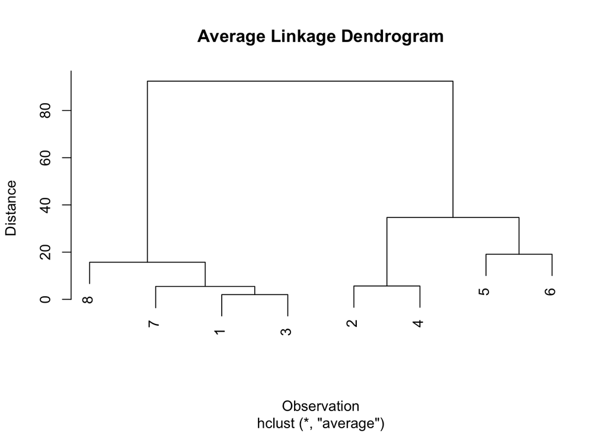

```r
plot(hclust.average, main = "Average Linkage Dendrogram",
     xlab = "Observation", ylab = "Distance")
```

Average linkage tends to produce **balanced** clusters and is less extreme than single or complete linkage.

# Summary

- **Average linkage** uses the *mean* of pairwise distances between clusters.
- Produces clusters with intermediate compactness and chaining tendencies.
- `hclust(method = "average")` confirms the correctness of manual updates.
- Commonly used for biological or ecological data with balanced similarity structures.